# p.college

MehrnazJalili

5/10/2021

# College data set

We try to predict the number of applications received

## part1: Data overview

#### explanation about data

```r
#Private: A factor with levels No and Yes indicating private or public university
# Apps : Number of applications received
#Accept:Number of applications accepted
#Enroll:Number of new students enrolled
#Top10perc:Pct. new students from top 10% of H.S. class
#Top25perc:Pct. new students from top 25% of H.S. class
#F.Undergrad: Number of fulltime undergraduates
#P.Undergrad:Number of parttime undergraduates
#Outstate: Out-of-state tuition
#Room.Board: Room and board costs
#Books: Estimated book costs
#Personal: Estimated personal spending
#PhD: Pct. of faculty with Ph.D.'s
#Terminal: Pct. of faculty with terminal degree
#S.F.Ratio: Student/faculty ratio
#perc.alumni: Pct. alumni who donate
#Expend: Instructional expenditure per student
# Grad.Rate: Graduation rate
```

```r
setwd("D:/data science")
# Reading in the data
data_assign<-read.csv("college.csv")
#Structure of data set
str(data_assign)
```

```
## 'data.frame':    777 obs. of  19 variables:
##  $ X          : chr  "Abilene Christian University" "Adelphi University" "Adrian College" "Agnes Scott College" ...
##  $ Private    : chr  "Yes" "Yes" "Yes" "Yes" ...
##  $ Apps       : int  1660 2186 1428 417 193 587 353 1899 1038 582 ...
##  $ Accept     : int  1232 1924 1097 349 146 479 340 1720 839 498 ...
##  $ Enroll     : int  721 512 336 137 55 158 103 489 227 172 ...
##  $ Top10perc  : int  23 16 22 60 16 38 17 37 30 21 ...
##  $ Top25perc  : int  52 29 50 89 44 62 45 68 63 44 ...
##  $ F.Undergrad: int  2885 2683 1036 510 249 678 416 1594 973 799 ...
##  $ P.Undergrad: int  537 1227 99 63 869 41 230 32 306 78 ...
##  $ Outstate   : int  7440 12280 11250 12960 7560 13500 13290 13868 15595 10468 ...
##  $ Room.Board : int  3300 6450 3750 5450 4120 3335 5720 4826 4400 3380 ...
##  $ Books      : int  450 750 400 450 800 500 500 450 300 660 ...
##  $ Personal   : int  2200 1500 1165 875 1500 675 1500 850 500 1800 ...
##  $ PhD        : int  70 29 53 92 76 67 90 89 79 40 ...
##  $ Terminal   : int  78 30 66 97 72 73 93 100 84 41 ...
##  $ S.F.Ratio  : num  18.1 12.2 12.9 7.7 11.9 9.4 11.5 13.7 11.3 11.5 ...
##  $ perc.alumni: int  12 16 30 37 2 11 26 37 23 15 ...
##  $ Expend     : int  7041 10527 8735 19016 10922 9727 8861 11487 11644 8991 ...
##  $ Grad.Rate  : int  60 56 54 59 15 55 63 73 80 52 ...
```

```r
#class of data set
class(data_assign)
```

```
## [1] "data.frame"
```

```r
#Dimensions of data set
dim(data_assign)
```

```
## [1] 777  19
```

```r
#Summary of  missing Variables
sum(is.na(data_assign))
```

```
## [1] 0
```

```r
#unique
length(unique(data_assign$X))
```

```
## [1] 777
```

**Note**: There isn’t any NA in data set

```r
#Summary of Variables
summary(data_assign)
```

```
##       X               Private               Apps           Accept
##  Length:777         Length:777         Min.   :   81   Min.   :   72
##  Class :character   Class :character   1st Qu.:  776   1st Qu.:  604
##  Mode  :character   Mode  :character   Median : 1558   Median : 1110
##                                        Mean   : 3002   Mean   : 2019
##                                        3rd Qu.: 3624   3rd Qu.: 2424
##                                        Max.   :48094   Max.   :26330
##      Enroll       Top10perc       Top25perc      F.Undergrad
##  Min.   :  35   Min.   : 1.00   Min.   :  9.0   Min.   :  139
##  1st Qu.: 242   1st Qu.:15.00   1st Qu.: 41.0   1st Qu.:  992
##  Median : 434   Median :23.00   Median : 54.0   Median : 1707
##  Mean   : 780   Mean   :27.56   Mean   : 55.8   Mean   : 3700
##  3rd Qu.: 902   3rd Qu.:35.00   3rd Qu.: 69.0   3rd Qu.: 4005
##  Max.   :6392   Max.   :96.00   Max.   :100.0   Max.   :31643
##   P.Undergrad         Outstate       Room.Board       Books
##  Min.   :    1.0   Min.   : 2340   Min.   :1780   Min.   :  96.0
##  1st Qu.:   95.0   1st Qu.: 7320   1st Qu.:3597   1st Qu.: 470.0
##  Median :  353.0   Median : 9990   Median :4200   Median : 500.0
##  Mean   :  855.3   Mean   :10441   Mean   :4358   Mean   : 549.4
##  3rd Qu.:  967.0   3rd Qu.:12925   3rd Qu.:5050   3rd Qu.: 600.0
##  Max.   :21836.0   Max.   :21700   Max.   :8124   Max.   :2340.0
##     Personal         PhD            Terminal       S.F.Ratio
##  Min.   : 250   Min.   :  8.00   Min.   : 24.0   Min.   : 2.50
##  1st Qu.: 850   1st Qu.: 62.00   1st Qu.: 71.0   1st Qu.:11.50
##  Median :1200   Median : 75.00   Median : 82.0   Median :13.60
##  Mean   :1341   Mean   : 72.66   Mean   : 79.7   Mean   :14.09
##  3rd Qu.:1700   3rd Qu.: 85.00   3rd Qu.: 92.0   3rd Qu.:16.50
##  Max.   :6800   Max.   :103.00   Max.   :100.0   Max.   :39.80
##   perc.alumni        Expend        Grad.Rate
##  Min.   : 0.00   Min.   : 3186   Min.   : 10.00
##  1st Qu.:13.00   1st Qu.: 6751   1st Qu.: 53.00
##  Median :21.00   Median : 8377   Median : 65.00
##  Mean   :22.74   Mean   : 9660   Mean   : 65.46
##  3rd Qu.:31.00   3rd Qu.:10830   3rd Qu.: 78.00
##  Max.   :64.00   Max.   :56233   Max.   :118.00
```

```r
#First rows of data frame
head(data_assign)
```

```
##                              X Private Apps Accept Enroll Top10perc Top25perc
## 1 Abilene Christian University     Yes 1660   1232    721        23        52
## 2           Adelphi University     Yes 2186   1924    512        16        29
## 3               Adrian College     Yes 1428   1097    336        22        50
## 4          Agnes Scott College     Yes  417    349    137        60        89
## 5    Alaska Pacific University     Yes  193    146     55        16        44
## 6            Albertson College     Yes  587    479    158        38        62
##   F.Undergrad P.Undergrad Outstate Room.Board Books Personal PhD Terminal
## 1        2885         537     7440       3300   450     2200  70       78
## 2        2683        1227    12280       6450   750     1500  29       30
## 3        1036          99    11250       3750   400     1165  53       66
## 4         510          63    12960       5450   450      875  92       97
## 5         249         869     7560       4120   800     1500  76       72
## 6         678          41    13500       3335   500      675  67       73
##   S.F.Ratio perc.alumni Expend Grad.Rate
## 1      18.1          12   7041        60
## 2      12.2          16  10527        56
## 3      12.9          30   8735        54
## 4       7.7          37  19016        59
## 5      11.9           2  10922        15
## 6       9.4          11   9727        55
```

```r
#last rows of data frame
tail(data_assign)
```

```
##                                   X Private  Apps Accept Enroll Top10perc
## 772 Worcester Polytechnic Institute     Yes  2768   2314    682        49
## 773         Worcester State College      No  2197   1515    543         4
## 774               Xavier University     Yes  1959   1805    695        24
## 775  Xavier University of Louisiana     Yes  2097   1915    695        34
## 776                 Yale University     Yes 10705   2453   1317        95
## 777    York College of Pennsylvania     Yes  2989   1855    691        28
##     Top25perc F.Undergrad P.Undergrad Outstate Room.Board Books Personal PhD
## 772        86        2802          86    15884       5370   530      730  92
## 773        26        3089        2029     6797       3900   500     1200  60
## 774        47        2849        1107    11520       4960   600     1250  73
## 775        61        2793         166     6900       4200   617      781  67
## 776        99        5217          83    19840       6510   630     2115  96
## 777        63        2988        1726     4990       3560   500     1250  75
##     Terminal S.F.Ratio perc.alumni Expend Grad.Rate
## 772       94      15.2          34  10774        82
## 773       60      21.0          14   4469        40
## 774       75      13.3          31   9189        83
## 775       75      14.4          20   8323        49
## 776       96       5.8          49  40386        99
## 777       75      18.1          28   4509        99
```

**Note**: see 1.1 in attached file.

## part2: Libraries

## part3: Data Preparation

```r
# change variable private to factor
data_assign$Private<-factor(data_assign$Private,levels = c("Yes","No"))
str(data_assign)
```

```
## 'data.frame':    777 obs. of  19 variables:
##  $ X          : chr  "Abilene Christian University" "Adelphi University" "Adrian College" "Agnes Scott College" ...
##  $ Private    : Factor w/ 2 levels "Yes","No": 1 1 1 1 1 1 1 1 1 1 ...
##  $ Apps       : int  1660 2186 1428 417 193 587 353 1899 1038 582 ...
##  $ Accept     : int  1232 1924 1097 349 146 479 340 1720 839 498 ...
##  $ Enroll     : int  721 512 336 137 55 158 103 489 227 172 ...
##  $ Top10perc  : int  23 16 22 60 16 38 17 37 30 21 ...
##  $ Top25perc  : int  52 29 50 89 44 62 45 68 63 44 ...
##  $ F.Undergrad: int  2885 2683 1036 510 249 678 416 1594 973 799 ...
##  $ P.Undergrad: int  537 1227 99 63 869 41 230 32 306 78 ...
##  $ Outstate   : int  7440 12280 11250 12960 7560 13500 13290 13868 15595 10468 ...
##  $ Room.Board : int  3300 6450 3750 5450 4120 3335 5720 4826 4400 3380 ...
##  $ Books      : int  450 750 400 450 800 500 500 450 300 660 ...
##  $ Personal   : int  2200 1500 1165 875 1500 675 1500 850 500 1800 ...
##  $ PhD        : int  70 29 53 92 76 67 90 89 79 40 ...
##  $ Terminal   : int  78 30 66 97 72 73 93 100 84 41 ...
##  $ S.F.Ratio  : num  18.1 12.2 12.9 7.7 11.9 9.4 11.5 13.7 11.3 11.5 ...
##  $ perc.alumni: int  12 16 30 37 2 11 26 37 23 15 ...
##  $ Expend     : int  7041 10527 8735 19016 10922 9727 8861 11487 11644 8991 ...
##  $ Grad.Rate  : int  60 56 54 59 15 55 63 73 80 52 ...
```

```r
#remove first variable
rownames(data_assign)<-data_assign[,1]
data_1<- data_assign[,-1]
str(data_1)
```

```
## 'data.frame':    777 obs. of  18 variables:
##  $ Private    : Factor w/ 2 levels "Yes","No": 1 1 1 1 1 1 1 1 1 1 ...
##  $ Apps       : int  1660 2186 1428 417 193 587 353 1899 1038 582 ...
##  $ Accept     : int  1232 1924 1097 349 146 479 340 1720 839 498 ...
##  $ Enroll     : int  721 512 336 137 55 158 103 489 227 172 ...
##  $ Top10perc  : int  23 16 22 60 16 38 17 37 30 21 ...
##  $ Top25perc  : int  52 29 50 89 44 62 45 68 63 44 ...
##  $ F.Undergrad: int  2885 2683 1036 510 249 678 416 1594 973 799 ...
##  $ P.Undergrad: int  537 1227 99 63 869 41 230 32 306 78 ...
##  $ Outstate   : int  7440 12280 11250 12960 7560 13500 13290 13868 15595 10468 ...
##  $ Room.Board : int  3300 6450 3750 5450 4120 3335 5720 4826 4400 3380 ...
##  $ Books      : int  450 750 400 450 800 500 500 450 300 660 ...
##  $ Personal   : int  2200 1500 1165 875 1500 675 1500 850 500 1800 ...
##  $ PhD        : int  70 29 53 92 76 67 90 89 79 40 ...
##  $ Terminal   : int  78 30 66 97 72 73 93 100 84 41 ...
##  $ S.F.Ratio  : num  18.1 12.2 12.9 7.7 11.9 9.4 11.5 13.7 11.3 11.5 ...
##  $ perc.alumni: int  12 16 30 37 2 11 26 37 23 15 ...
##  $ Expend     : int  7041 10527 8735 19016 10922 9727 8861 11487 11644 8991 ...
##  $ Grad.Rate  : int  60 56 54 59 15 55 63 73 80 52 ...
```

```r
summary(data_1)
```

```
##  Private        Apps           Accept          Enroll       Top10perc
##  Yes:565   Min.   :   81   Min.   :   72   Min.   :  35   Min.   : 1.00
##  No :212   1st Qu.:  776   1st Qu.:  604   1st Qu.: 242   1st Qu.:15.00
##            Median : 1558   Median : 1110   Median : 434   Median :23.00
##            Mean   : 3002   Mean   : 2019   Mean   : 780   Mean   :27.56
##            3rd Qu.: 3624   3rd Qu.: 2424   3rd Qu.: 902   3rd Qu.:35.00
##            Max.   :48094   Max.   :26330   Max.   :6392   Max.   :96.00
##    Top25perc      F.Undergrad     P.Undergrad         Outstate
##  Min.   :  9.0   Min.   :  139   Min.   :    1.0   Min.   : 2340
##  1st Qu.: 41.0   1st Qu.:  992   1st Qu.:   95.0   1st Qu.: 7320
##  Median : 54.0   Median : 1707   Median :  353.0   Median : 9990
##  Mean   : 55.8   Mean   : 3700   Mean   :  855.3   Mean   :10441
##  3rd Qu.: 69.0   3rd Qu.: 4005   3rd Qu.:  967.0   3rd Qu.:12925
##  Max.   :100.0   Max.   :31643   Max.   :21836.0   Max.   :21700
##    Room.Board       Books           Personal         PhD
##  Min.   :1780   Min.   :  96.0   Min.   : 250   Min.   :  8.00
##  1st Qu.:3597   1st Qu.: 470.0   1st Qu.: 850   1st Qu.: 62.00
##  Median :4200   Median : 500.0   Median :1200   Median : 75.00
##  Mean   :4358   Mean   : 549.4   Mean   :1341   Mean   : 72.66
##  3rd Qu.:5050   3rd Qu.: 600.0   3rd Qu.:1700   3rd Qu.: 85.00
##  Max.   :8124   Max.   :2340.0   Max.   :6800   Max.   :103.00
##     Terminal       S.F.Ratio      perc.alumni        Expend
##  Min.   : 24.0   Min.   : 2.50   Min.   : 0.00   Min.   : 3186
##  1st Qu.: 71.0   1st Qu.:11.50   1st Qu.:13.00   1st Qu.: 6751
##  Median : 82.0   Median :13.60   Median :21.00   Median : 8377
##  Mean   : 79.7   Mean   :14.09   Mean   :22.74   Mean   : 9660
##  3rd Qu.: 92.0   3rd Qu.:16.50   3rd Qu.:31.00   3rd Qu.:10830
##  Max.   :100.0   Max.   :39.80   Max.   :64.00   Max.   :56233
##    Grad.Rate
##  Min.   : 10.00
##  1st Qu.: 53.00
##  Median : 65.00
##  Mean   : 65.46
##  3rd Qu.: 78.00
##  Max.   :118.00
```

```r
# Create a new qualitative variable, called Elite, by binning the Top10perc variable.
# We are going to divide universities into two groups based on whether or not the proportion of students
# coming from the top 10% of their high school classes exceeds 50%.
Elite <- rep("No", nrow(data_1))
Elite[data_1$Top10perc > 50] <- "Yes"
Elite <- as.factor(Elite)
data_1 <- data.frame(data_1, Elite)
```

## part4: Exploratory analysis

```r
#how many elite universities there are
summary(data_1$Elite)
```

```
##  No Yes
## 699  78
```

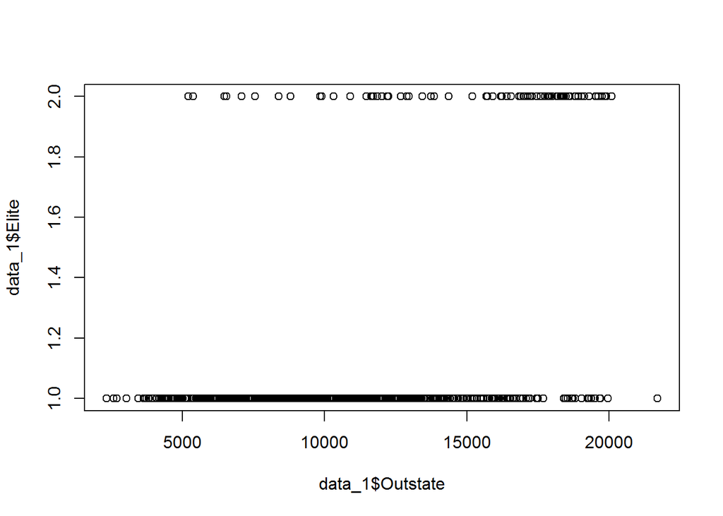

```r
plot(data_1$Outstate,data_1$Elite)
```

**Note**: Outstate variable should be analysis through logestic regression.

```r
row.names(data_1[data_1$PhD >100,])
```

```
## [1] "Texas A&M University at Galveston"
```

```r
row.names(data_1[data_1$Apps>25000, ])
```

```
## [1] "Rutgers at New Brunswick"
```

**Note**: Rutgers at New Brunswick is an isolated university

```r
row.names(data_1[data_1$Grad.Rate >100,])
```

```
## [1] "Cazenovia College"
```

```r
# university with the most students in the top 10% of class
row.names(data_1)[which.max(data_1$Top10perc)]
```

```
## [1] "Massachusetts Institute of Technology"
```

```r
# lowest acceptance rate
acceptance_rate <- data_1$Accept / data_1$Apps
row.names(data_1)[which.min(acceptance_rate)]
```

```
## [1] "Princeton University"
```

```r
# highest acceptance rate
row.names(data_1)[which.max(acceptance_rate)]
```

```
## [1] "Emporia State University"
```

## Part 5: Predictive Models

### Part 5 - a: Correlation Analysis

#### Scatter Plot

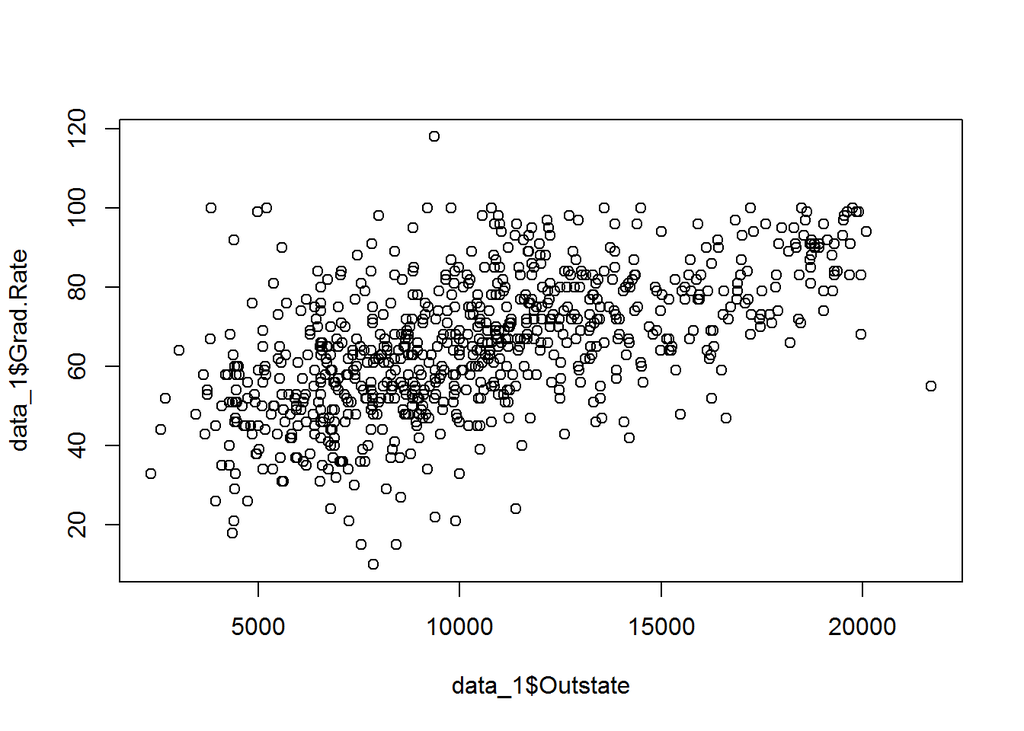

```r
#Relation between out of state tution fees and Graduation Rate
plot(data_1$Grad.Rate ~data_1$Outstate)
```

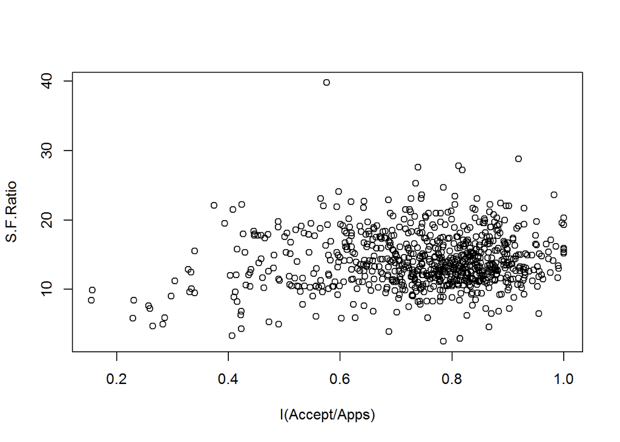

```r
# Colleges with low acceptance rate tend to have low S:F ratio.
plot(S.F.Ratio ~ I(Accept/Apps), data = data_1)
```

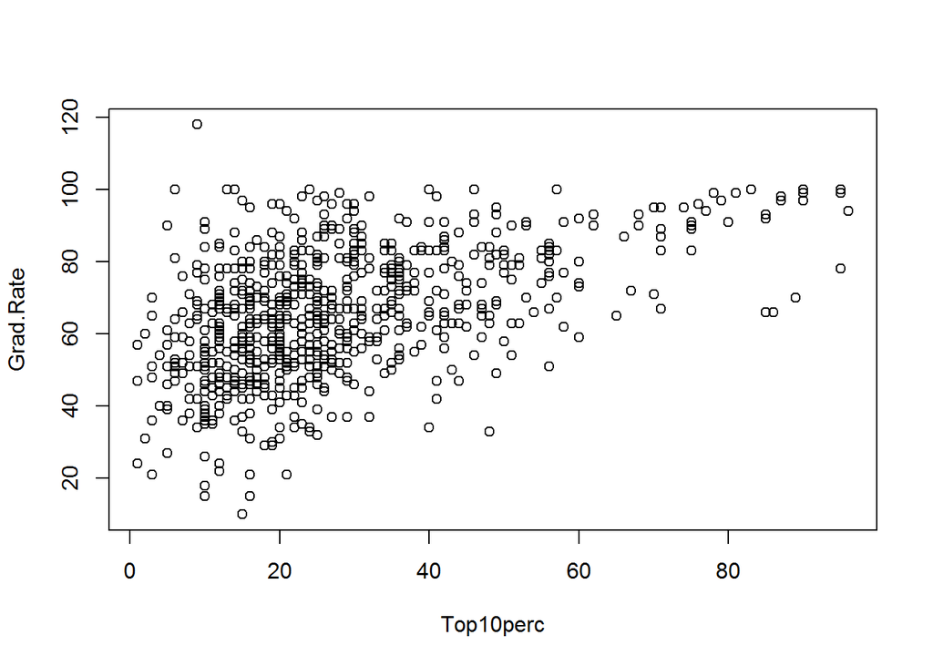

```r
plot(Grad.Rate ~ Top10perc, data = data_1)
```

**Note**: Colleges with the most students from top 10% perc don’t necessarily have the highest graduation rate. Also, rate > 100 is erroneous!

**Note**: It seems that there is a linear relation between Grad rate with Outstate and Grad rate with Top10perc.

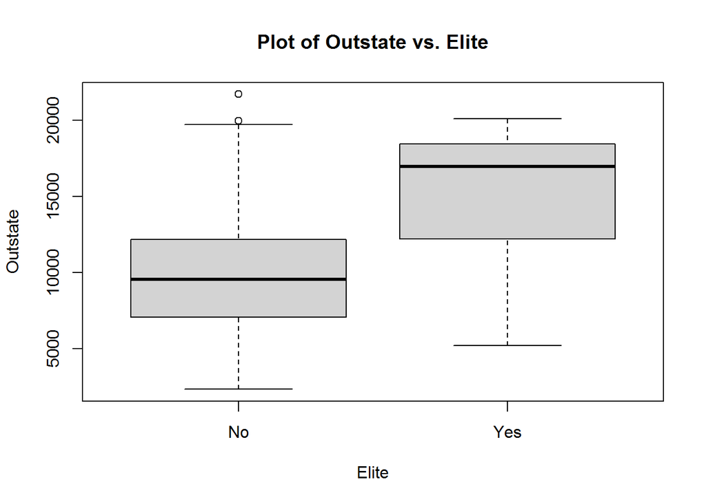

```r
plot(data_1$Elite, data_1$Outstate, main = "Plot of Outstate vs. Elite", xlab = "Elite", ylab = "Outstate")
```

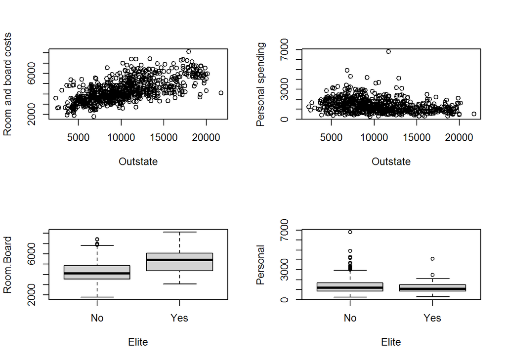

```r
par(mfrow = c(2,2))
plot(data_1$Outstate, data_1$Room.Board, xlab = "Outstate", ylab = "Room and board costs")
plot(data_1$Outstate, data_1$Personal, xlab = "Outstate", ylab = "Personal spending")
plot(Elite, data_1$Room.Board, xlab = "Elite", ylab = "Room.Board")
plot(Elite, data_1$Personal, xlab = "Elite", ylab = "Personal")
```

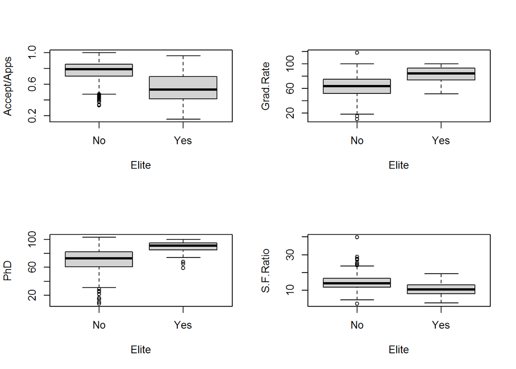

```r
par(mfrow = c(2,2))
plot(Elite, data_1$Accept/data_1$Apps, xlab = "Elite", ylab = "Accept/Apps")
plot(Elite, data_1$Grad.Rate, xlab = "Elite", ylab = "Grad.Rate")
plot(Elite, data_1$PhD, xlab = "Elite", ylab = "PhD")
plot(Elite, data_1$S.F.Ratio, xlab = "Elite", ylab = "S.F.Ratio")
```

**Note**: Elite colleges have lower acceptance rates and higher graduation rates than non-elite colleges. Elite colleges also have a higher percentage of faculty with PhDs and a lower student-faculty ratio compared to non-elite colleges.

**Note**: There isn’t any linear relationship between Outstate and personal spending.

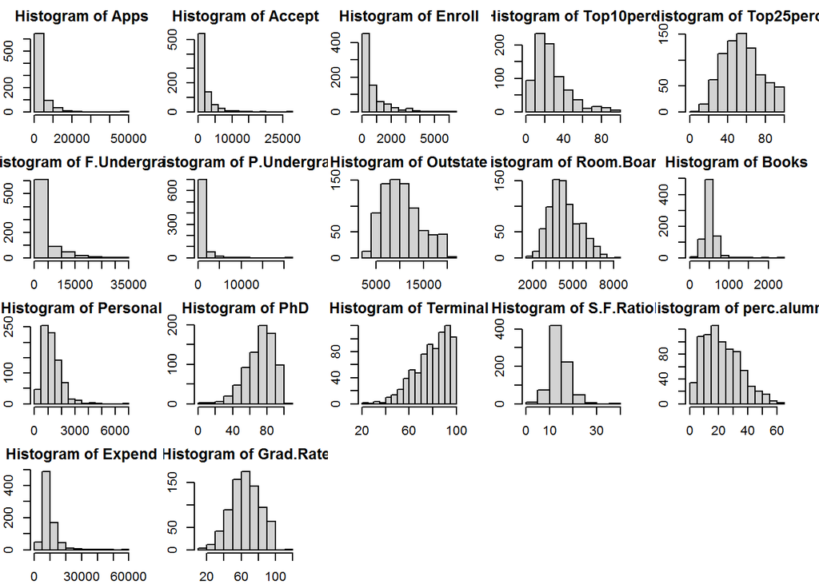

```r
par(mar=c(2,2,2,2))
par(mfrow=c(4,5))
figure_1<- for(i in 2:18){
  hist(data_1[,i],xlab="", main = paste("Histogram of",names(data_1)[i]))
}
par(mar=c(5, 4, 4, 2) + 0.1)
par(mfrow=c(1,1))
```

```r
#frequency of private and public universities.
table(data_1$Private)
```

```
##
## Yes  No
## 565 212
```

```r
# correlation between variables
cor_table<-round(cor(data_1[,2:18]),2)
cor_table
```

```
##              Apps Accept Enroll Top10perc Top25perc F.Undergrad P.Undergrad
## Apps         1.00   0.94   0.85      0.34      0.35        0.81        0.40
## Accept       0.94   1.00   0.91      0.19      0.25        0.87        0.44
## Enroll       0.85   0.91   1.00      0.18      0.23        0.96        0.51
## Top10perc    0.34   0.19   0.18      1.00      0.89        0.14       -0.11
## Top25perc    0.35   0.25   0.23      0.89      1.00        0.20       -0.05
## F.Undergrad  0.81   0.87   0.96      0.14      0.20        1.00        0.57
## P.Undergrad  0.40   0.44   0.51     -0.11     -0.05        0.57        1.00
## Outstate     0.05  -0.03  -0.16      0.56      0.49       -0.22       -0.25
## Room.Board   0.16   0.09  -0.04      0.37      0.33       -0.07       -0.06
## Books        0.13   0.11   0.11      0.12      0.12        0.12        0.08
## Personal     0.18   0.20   0.28     -0.09     -0.08        0.32        0.32
## PhD          0.39   0.36   0.33      0.53      0.55        0.32        0.15
## Terminal     0.37   0.34   0.31      0.49      0.52        0.30        0.14
## S.F.Ratio    0.10   0.18   0.24     -0.38     -0.29        0.28        0.23
## perc.alumni -0.09  -0.16  -0.18      0.46      0.42       -0.23       -0.28
## Expend       0.26   0.12   0.06      0.66      0.53        0.02       -0.08
## Grad.Rate    0.15   0.07  -0.02      0.49      0.48       -0.08       -0.26
##             Outstate Room.Board Books Personal   PhD Terminal S.F.Ratio
## Apps            0.05       0.16  0.13     0.18  0.39     0.37      0.10
## Accept         -0.03       0.09  0.11     0.20  0.36     0.34      0.18
## Enroll         -0.16      -0.04  0.11     0.28  0.33     0.31      0.24
## Top10perc       0.56       0.37  0.12    -0.09  0.53     0.49     -0.38
## Top25perc       0.49       0.33  0.12    -0.08  0.55     0.52     -0.29
## F.Undergrad    -0.22      -0.07  0.12     0.32  0.32     0.30      0.28
## P.Undergrad    -0.25      -0.06  0.08     0.32  0.15     0.14      0.23
## Outstate        1.00       0.65  0.04    -0.30  0.38     0.41     -0.55
## Room.Board      0.65       1.00  0.13    -0.20  0.33     0.37     -0.36
## Books           0.04       0.13  1.00     0.18  0.03     0.10     -0.03
## Personal       -0.30      -0.20  0.18     1.00 -0.01    -0.03      0.14
## PhD             0.38       0.33  0.03    -0.01  1.00     0.85     -0.13
## Terminal        0.41       0.37  0.10    -0.03  0.85     1.00     -0.16
## S.F.Ratio      -0.55      -0.36 -0.03     0.14 -0.13    -0.16      1.00
## perc.alumni     0.57       0.27 -0.04    -0.29  0.25     0.27     -0.40
## Expend          0.67       0.50  0.11    -0.10  0.43     0.44     -0.58
## Grad.Rate       0.57       0.42  0.00    -0.27  0.31     0.29     -0.31
##             perc.alumni Expend Grad.Rate
## Apps              -0.09   0.26      0.15
## Accept            -0.16   0.12      0.07
## Enroll            -0.18   0.06     -0.02
## Top10perc          0.46   0.66      0.49
## Top25perc          0.42   0.53      0.48
## F.Undergrad       -0.23   0.02     -0.08
## P.Undergrad       -0.28  -0.08     -0.26
## Outstate           0.57   0.67      0.57
## Room.Board         0.27   0.50      0.42
## Books             -0.04   0.11      0.00
## Personal          -0.29  -0.10     -0.27
## PhD                0.25   0.43      0.31
## Terminal           0.27   0.44      0.29
## S.F.Ratio         -0.40  -0.58     -0.31
## perc.alumni        1.00   0.42      0.49
## Expend             0.42   1.00      0.39
## Grad.Rate          0.49   0.39      1.00
```

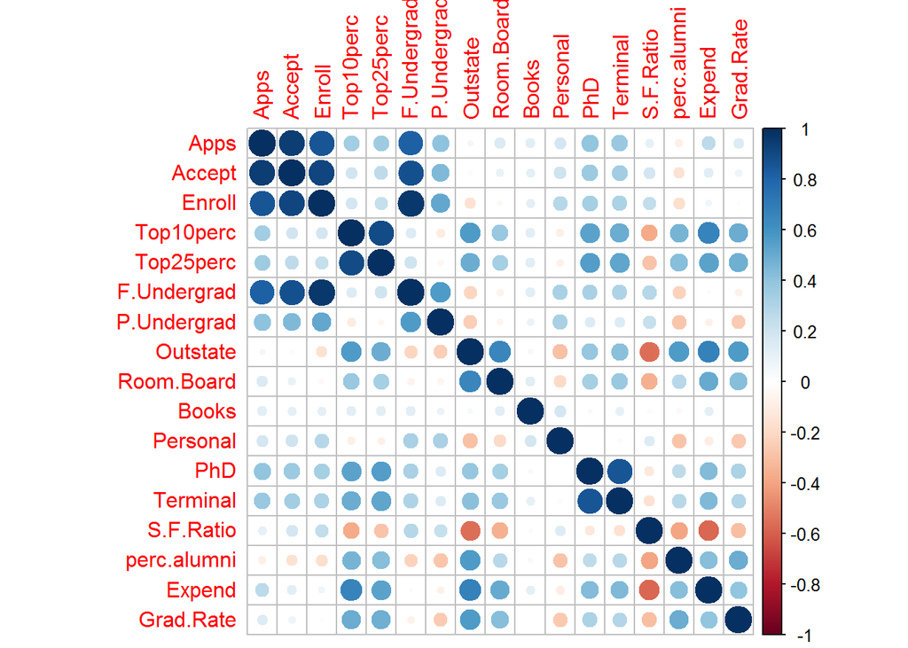

```r
corrplot::corrplot(cor_table)
```

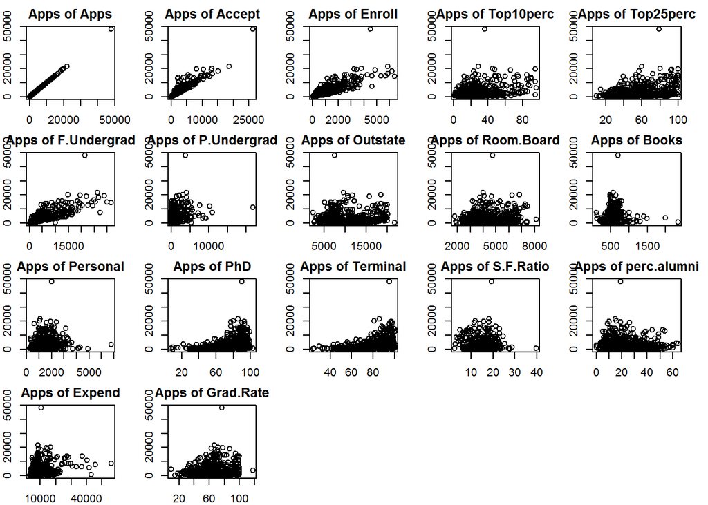

```r
#There is the most  positive correlation in bold points
#The fainter the color of the points have the lower the correlation between the variables
par(mar=c(2,2,2,2))
par(mfrow=c(4,5))
for(i in 2:18){
  plot(data_1[,i],data_1$Apps,xlab="", main = paste("Apps of",names(data_1)[i]))
}
par(mar=c(5, 4, 4, 2) + 0.1)
par(mfrow=c(1,1))
```

```r
tapply(data_1$Apps,list(data_1$Private),mean)
```

```
##      Yes       No
## 1977.929 5729.920
```

**Note**: Out-of-state tuition fees have a positive relationship with room and board costs. However, personal spending seems comparable across individuals regardless of whether they attend an elite college with higher tuition fees.

**Note**: However, colleges with the highest number of students from the top 10% of their high school class do not necessarily have the highest graduation rate. In addition, a closer inspection of the graduation rate also revealed a rate of more than 100, which is likely to be erroneous.

**Note**: Number of applications received with Number of applications accepted and Number of new students enrolled and Number of fulltime undergraduates has linear relationship and high corrolated.

### part5-b: split data set

```r
#Divide Dataset into Train and Test
set.seed(1234)
train_case<-sample(1:nrow(data_1),0.8*nrow(data_1))
train<- data_1[train_case,]
test<- data_1[-train_case,]
#dimension of train dataset
dim(train)
```

```
## [1] 621  19
```

```r
#dimension of test dataset
dim(test)
```

```
## [1] 156  19
```

```r
summary(train)
```

```
##  Private        Apps           Accept          Enroll         Top10perc
##  Yes:452   Min.   :  100   Min.   :   90   Min.   :  35.0   Min.   : 1.00
##  No :169   1st Qu.:  805   1st Qu.:  632   1st Qu.: 252.0   1st Qu.:15.00
##            Median : 1584   Median : 1188   Median : 444.0   Median :24.00
##            Mean   : 3054   Mean   : 2063   Mean   : 795.2   Mean   :27.48
##            3rd Qu.: 3646   3rd Qu.: 2446   3rd Qu.: 913.0   3rd Qu.:35.00
##            Max.   :48094   Max.   :26330   Max.   :6180.0   Max.   :96.00
##    Top25perc       F.Undergrad     P.Undergrad         Outstate
##  Min.   :  9.00   Min.   :  199   Min.   :    1.0   Min.   : 2340
##  1st Qu.: 41.00   1st Qu.: 1035   1st Qu.:   94.0   1st Qu.: 7344
##  Median : 54.00   Median : 1757   Median :  374.0   Median :10000
##  Mean   : 55.79   Mean   : 3790   Mean   :  879.6   Mean   :10481
##  3rd Qu.: 69.00   3rd Qu.: 4291   3rd Qu.: 1075.0   3rd Qu.:13000
##  Max.   :100.00   Max.   :30017   Max.   :21836.0   Max.   :21700
##    Room.Board       Books           Personal         PhD
##  Min.   :1880   Min.   :  96.0   Min.   : 300   Min.   :  8.00
##  1st Qu.:3600   1st Qu.: 450.0   1st Qu.: 850   1st Qu.: 62.00
##  Median :4194   Median : 500.0   Median :1200   Median : 75.00
##  Mean   :4362   Mean   : 550.5   Mean   :1343   Mean   : 72.53
##  3rd Qu.:5045   3rd Qu.: 600.0   3rd Qu.:1700   3rd Qu.: 85.00
##  Max.   :8124   Max.   :2340.0   Max.   :6800   Max.   :103.00
##     Terminal        S.F.Ratio      perc.alumni        Expend
##  Min.   : 24.00   Min.   : 2.50   Min.   : 0.00   Min.   : 3186
##  1st Qu.: 71.00   1st Qu.:11.50   1st Qu.:13.00   1st Qu.: 6817
##  Median : 82.00   Median :13.50   Median :21.00   Median : 8324
##  Mean   : 79.74   Mean   :14.07   Mean   :22.89   Mean   : 9668
##  3rd Qu.: 92.00   3rd Qu.:16.40   3rd Qu.:31.00   3rd Qu.:10872
##  Max.   :100.00   Max.   :39.80   Max.   :64.00   Max.   :56233
##    Grad.Rate      Elite
##  Min.   : 10.00   No :557
##  1st Qu.: 53.00   Yes: 64
##  Median : 65.00
##  Mean   : 65.52
##  3rd Qu.: 77.00
##  Max.   :118.00
```

```r
summary(test)
```

```
##  Private        Apps             Accept          Enroll         Top10perc
##  Yes:113   Min.   :   81.0   Min.   :   72   Min.   :  51.0   Min.   : 5.00
##  No : 43   1st Qu.:  643.2   1st Qu.:  497   1st Qu.: 221.8   1st Qu.:15.00
##            Median : 1327.5   Median :  979   Median : 365.0   Median :23.00
##            Mean   : 2791.9   Mean   : 1842   Mean   : 719.3   Mean   :27.87
##            3rd Qu.: 3372.0   3rd Qu.: 2296   3rd Qu.: 842.5   3rd Qu.:35.25
##            Max.   :15698.0   Max.   :11652   Max.   :6392.0   Max.   :95.00
##    Top25perc       F.Undergrad       P.Undergrad         Outstate
##  Min.   : 21.00   Min.   :  139.0   Min.   :    1.0   Min.   : 3460
##  1st Qu.: 40.75   1st Qu.:  911.5   1st Qu.:  100.8   1st Qu.: 7092
##  Median : 54.00   Median : 1491.0   Median :  319.5   Median : 9600
##  Mean   : 55.81   Mean   : 3341.6   Mean   :  758.7   Mean   :10281
##  3rd Qu.: 67.25   3rd Qu.: 3801.2   3rd Qu.:  865.2   3rd Qu.:12506
##  Max.   :100.00   Max.   :31643.0   Max.   :10962.0   Max.   :19840
##    Room.Board       Books           Personal           PhD
##  Min.   :1780   Min.   : 110.0   Min.   : 250.0   Min.   : 29.00
##  1st Qu.:3554   1st Qu.: 498.5   1st Qu.: 878.8   1st Qu.: 61.00
##  Median :4245   Median : 500.0   Median :1220.0   Median : 75.00
##  Mean   :4340   Mean   : 544.9   Mean   :1332.0   Mean   : 73.19
##  3rd Qu.:5202   3rd Qu.: 600.0   3rd Qu.:1619.0   3rd Qu.: 88.00
##  Max.   :7270   Max.   :1100.0   Max.   :4913.0   Max.   :100.00
##     Terminal        S.F.Ratio      perc.alumni        Expend
##  Min.   : 33.00   Min.   : 2.90   Min.   : 0.00   Min.   : 3733
##  1st Qu.: 71.00   1st Qu.:11.45   1st Qu.:13.00   1st Qu.: 6612
##  Median : 82.00   Median :14.25   Median :20.00   Median : 8535
##  Mean   : 79.57   Mean   :14.17   Mean   :22.15   Mean   : 9630
##  3rd Qu.: 92.00   3rd Qu.:16.93   3rd Qu.:31.00   3rd Qu.:10653
##  Max.   :100.00   Max.   :27.80   Max.   :53.00   Max.   :40386
##    Grad.Rate      Elite
##  Min.   : 15.00   No :142
##  1st Qu.: 53.00   Yes: 14
##  Median : 65.00
##  Mean   : 65.22
##  3rd Qu.: 79.00
##  Max.   :100.00
```

## part6: model regression

### part6-a: Linear model1

```r
#linear model with all parameters
model1_reg<-lm(Apps~.,data = train)
summary(model1_reg)
```

```
##
## Call:
## lm(formula = Apps ~ ., data = train)
##
## Residuals:
##     Min      1Q  Median      3Q     Max
## -4979.6  -419.5   -20.1   335.4  7537.4
##
## Coefficients:
##               Estimate Std. Error t value Pr(>|t|)
## (Intercept) -776.83627  450.97408  -1.723 0.085479 .
## PrivateNo    519.07984  161.26335   3.219 0.001356 **
## Accept         1.61073    0.04520  35.635  < 2e-16 ***
## Enroll        -1.01046    0.20543  -4.919 1.13e-06 ***
## Top10perc     45.80868    7.56475   6.056 2.46e-09 ***
## Top25perc    -11.28316    5.17586  -2.180 0.029647 *
## F.Undergrad    0.07070    0.03514   2.012 0.044637 *
## P.Undergrad    0.05599    0.03663   1.529 0.126894
## Outstate      -0.07584    0.02169  -3.496 0.000508 ***
## Room.Board     0.13986    0.05443   2.569 0.010428 *
## Books         -0.05422    0.26061  -0.208 0.835260
## Personal       0.03645    0.07213   0.505 0.613552
## PhD           -8.21049    5.24606  -1.565 0.118090
## Terminal      -3.90145    5.72278  -0.682 0.495665
## S.F.Ratio      5.86870   14.93762   0.393 0.694547
## perc.alumni   -1.95316    4.75960  -0.410 0.681686
## Expend         0.06037    0.01395   4.328 1.76e-05 ***
## Grad.Rate      9.79697    3.46177   2.830 0.004809 **
## EliteYes     314.93435  230.22394   1.368 0.171839
## ---
## Signif. codes:  0 '***' 0.001 '**' 0.01 '*' 0.05 '.' 0.1 ' ' 1
##
## Residual standard error: 1064 on 602 degrees of freedom
## Multiple R-squared:  0.9304, Adjusted R-squared:  0.9283
## F-statistic: 446.8 on 18 and 602 DF,  p-value: < 2.2e-16
```

```r
#The p-values for the coefficients indicate whether these relationships are statistically significant
```

**Note**: P.Undergrad, Books, Personal, Phd, Terminal, S.F.Ratio, Perc.alumni and Elite are not statistically significant predictors of the number of Apps in model1_reg.

#### check normality assumption

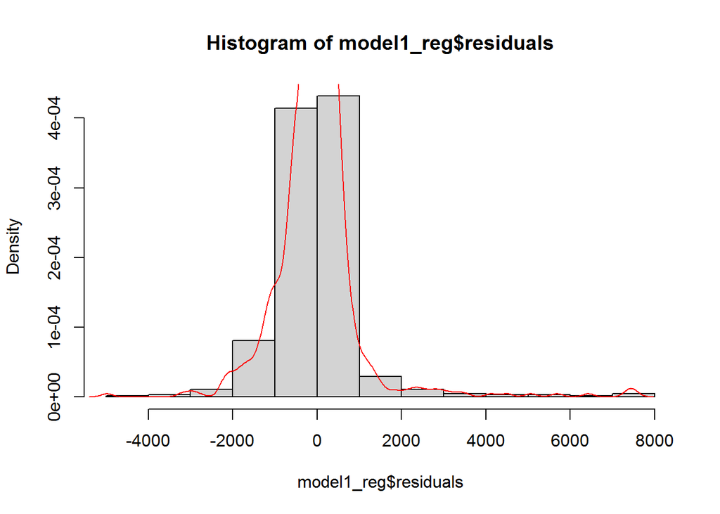

```r
hist(model1_reg$residuals,probability = TRUE)
lines(density(model1_reg$residuals),col="red")
```

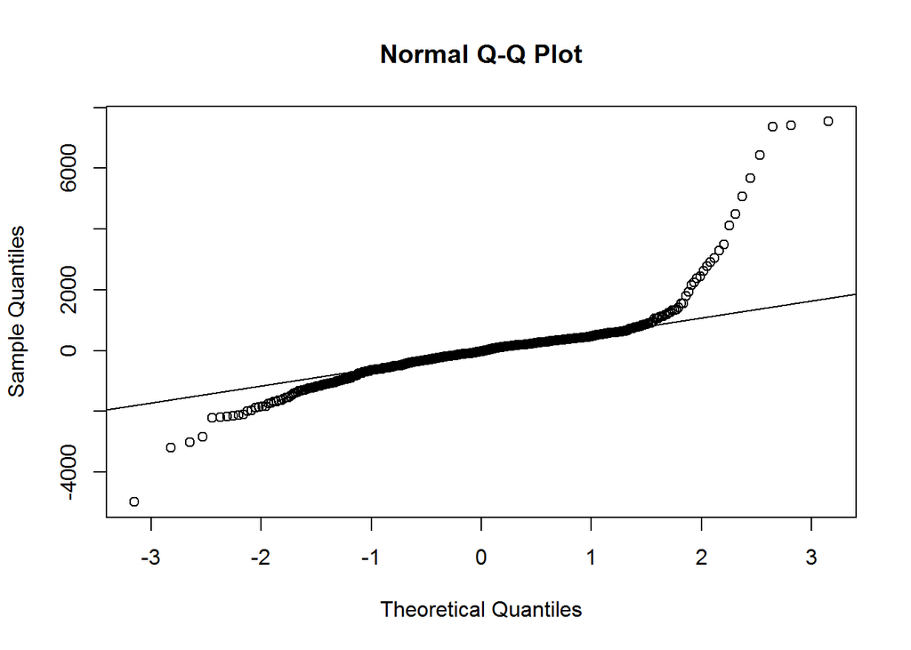

```r
qqnorm(model1_reg$residuals)
qqline(model1_reg$residuals)
```

```r
#Test for Skewness and Kurtosis
moments::anscombe.test(model1_reg$residuals)
```

```
##
##  Anscombe-Glynn kurtosis test
##
## data:  model1_reg$residuals
## kurt = 20.427, z = 12.619, p-value < 2.2e-16
## alternative hypothesis: kurtosis is not equal to 3
```

```r
moments::jarque.test(model1_reg$residuals)
```

```
##
##  Jarque-Bera Normality Test
##
## data:  model1_reg$residuals
## JB = 8533.7, p-value < 2.2e-16
## alternative hypothesis: greater
```

```r
#p-value < 0.05 reject normality assumption
```

**Note**: residuals in model1_reg are not normally distributed.(see 1.2)

#### prediction

```r
pred_model1_reg<-predict(model1_reg,test)
```

#### Absolute errors

```r
#We compute absolute errors to predict the best model which has the lowest absolute errors against other ones.
abs_err_model1_reg <- abs(pred_model1_reg - test$Apps)
mean(abs_err_model1_reg)
```

```
## [1] 600.7534
```

```r
median(abs_err_model1_reg)
```

```
## [1] 389.7777
```

```r
sd(abs_err_model1_reg)
```

```
## [1] 747.6524
```

```r
IQR(abs_err_model1_reg)
```

```
## [1] 557.9159
```

```r
min(abs_err_model1_reg)
```

```
## [1] 0.7324318
```

```r
max(abs_err_model1_reg)
```

```
## [1] 5310.044
```

```r
range(abs_err_model1_reg)
```

```
## [1]    0.7324318 5310.0439130
```

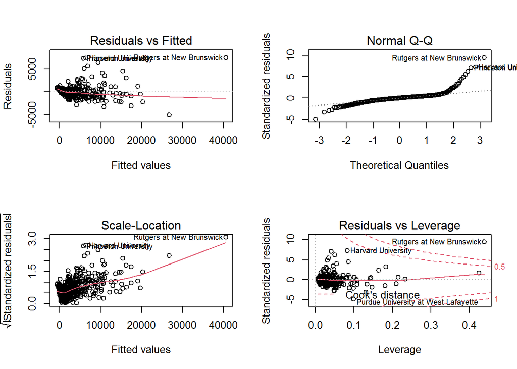

```r
mse_model1_reg<-mean((test$Apps-pred_model1_reg )^2)
par(mfrow=c(2,2))
plot(model1_reg)
```

```r
par(mfrow=c(1,1))
```

**Note**: see(1.3)

#### plot actual vs predicted

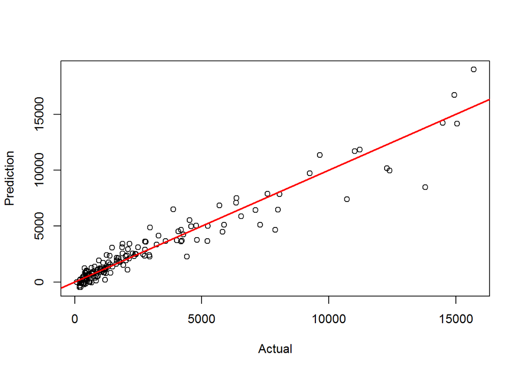

```r
plot(test$Apps, pred_model1_reg, xlab = "Actual", ylab = "Prediction")
abline(a = 0, b = 1, col = "red", lwd = 2)
```

### part6-b: significant variable on linear regression model

```r
model2_reg<-lm(Apps~Private+Accept+Enroll +Top10perc+Top25perc+F.Undergrad+Outstate+Room.Board +Expend+Grad.Rate+Terminal,data = train )
summary(model2_reg)
```

```
##
## Call:
## lm(formula = Apps ~ Private + Accept + Enroll + Top10perc + Top25perc +
##     F.Undergrad + Outstate + Room.Board + Expend + Grad.Rate +
##     Terminal, data = train)
##
## Residuals:
##     Min      1Q  Median      3Q     Max
## -5054.8  -445.0     0.8   315.0  7530.7
##
## Coefficients:
##               Estimate Std. Error t value Pr(>|t|)
## (Intercept) -676.03581  316.94304  -2.133 0.033325 *
## PrivateNo    548.22917  154.95844   3.538 0.000434 ***
## Accept         1.60918    0.04442  36.224  < 2e-16 ***
## Enroll        -1.01518    0.20440  -4.967 8.86e-07 ***
## Top10perc     49.48684    6.19452   7.989 6.84e-15 ***
## Top25perc    -12.92669    5.05880  -2.555 0.010852 *
## F.Undergrad    0.08022    0.03419   2.346 0.019280 *
## Outstate      -0.08452    0.02078  -4.067 5.40e-05 ***
## Room.Board     0.16225    0.05232   3.101 0.002018 **
## Expend         0.06171    0.01286   4.799 2.01e-06 ***
## Grad.Rate      8.16342    3.28504   2.485 0.013221 *
## Terminal     -10.38175    3.92566  -2.645 0.008390 **
## ---
## Signif. codes:  0 '***' 0.001 '**' 0.01 '*' 0.05 '.' 0.1 ' ' 1
##
## Residual standard error: 1064 on 609 degrees of freedom
## Multiple R-squared:  0.9295, Adjusted R-squared:  0.9282
## F-statistic:   730 on 11 and 609 DF,  p-value: < 2.2e-16
```

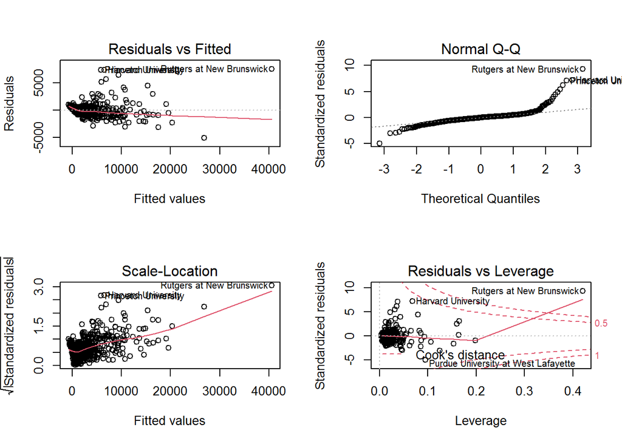

```r
par(mfrow=c(2, 2))
plot(model2_reg)
```

```r
par(mfrow=c(1,1))
```

**Note** see(1.4)

#### check normallity assumption

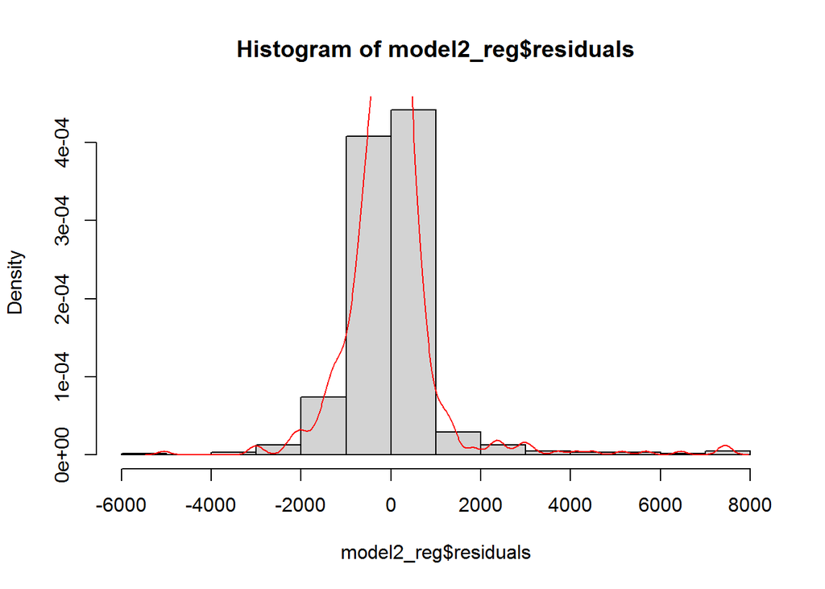

```r
hist(model2_reg$residuals,probability = TRUE)
lines(density(model2_reg$residuals),col="red")
```

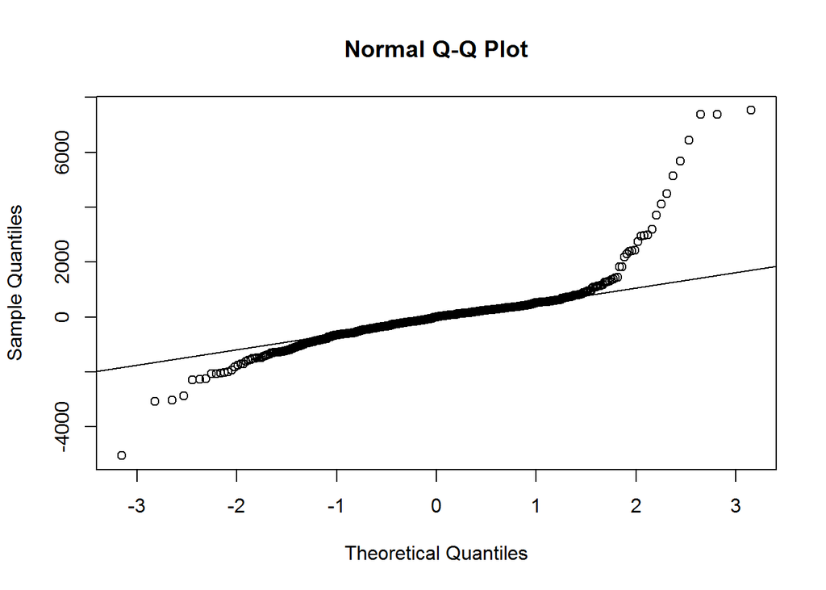

```r
qqnorm(model2_reg$residuals)
qqline(model2_reg$residuals)
```

```r
#Test for Skewness and Kurtosis
#p-value < 0.05 reject normality assumption
moments::anscombe.test(model2_reg$residuals)
```

```
##
##  Anscombe-Glynn kurtosis test
##
## data:  model2_reg$residuals
## kurt = 20.134, z = 12.572, p-value < 2.2e-16
## alternative hypothesis: kurtosis is not equal to 3
```

```r
moments::jarque.test(model2_reg$residuals)
```

```
##
##  Jarque-Bera Normality Test
##
## data:  model2_reg$residuals
## JB = 8272.7, p-value < 2.2e-16
## alternative hypothesis: greater
```

**Note**: residuals in model2_reg are not normally distributed.

### part6-c: variance inflation factor (VIF)

#### Check Multicolinearity

```r
#there is multicollinearity if VIF > 10.
car::vif(model1_reg)
```

```
##     Private      Accept      Enroll   Top10perc   Top25perc F.Undergrad
##    2.826245    7.102755   20.102129    9.646098    5.752362   16.329803
## P.Undergrad    Outstate  Room.Board       Books    Personal         PhD
##    1.761280    4.171891    1.943598    1.111118    1.304655    3.935662
##    Terminal   S.F.Ratio perc.alumni      Expend   Grad.Rate       Elite
##    3.857647    1.858720    1.931305    2.862200    1.888306    2.688125
```

```r
car::vif(model2_reg)
```

```
##     Private      Accept      Enroll   Top10perc   Top25perc F.Undergrad
##    2.607927    6.856193   19.887472    6.464046    5.491667   15.453524
##    Outstate  Room.Board      Expend   Grad.Rate    Terminal
##    3.826749    1.794673    2.431293    1.699352    1.814097
```

**Note** there is multicollinearity between Enroll & F.Undergrad.

#### prediction

```r
pred_model2_reg<-predict(model2_reg,test)
```

#### absolute errors

```
## [1] 613.0008
```

```
## [1] 395.8712
```

```
## [1] 739.9849
```

```
## [1] 581.6747
```

```
## [1] 5.143498
```

```
## [1] 5255.805
```

```
## [1]    5.143498 5255.804635
```

#### plot actual vs predicted

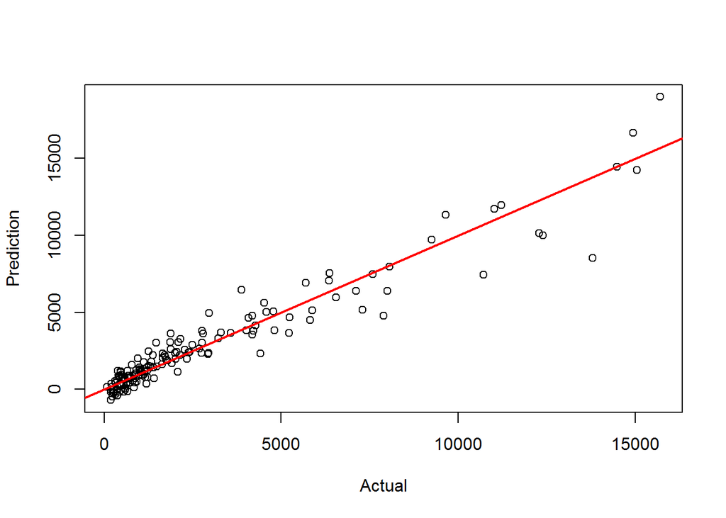

```r
plot(test$Apps, pred_model2_reg, xlab = "Actual", ylab = "Prediction")
abline(a = 0, b = 1, col = "red", lwd = 2)
```

**Note** see (1.5)

## part7: Identify outliers

### part7-a: cook’s distance method

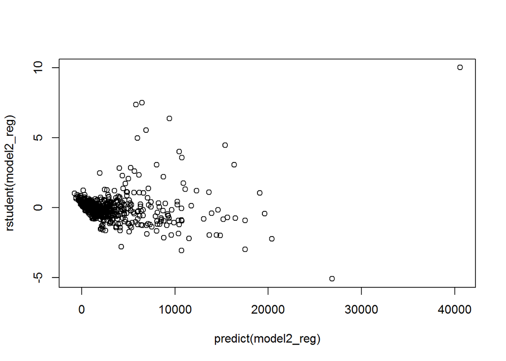

```r
plot(predict(model2_reg),rstudent(model2_reg))
```

**Note**: There are possible outliers as seen in the plot of studentized residuals because there are data with a value greater than 3.

```r
cooks_model2_reg<-cooks.distance(model2_reg)
cooks_model2_reg[cooks_model2_reg>1]
```

```
## Rutgers at New Brunswick
##                  5.22683
```

**Note** Cooks distance of Rutgers at New Brunswick is greater than 1.

### part7-b: Tukey’s method

```r
tukey_model2_reg<-quantile(data_1$Apps,probs = 0.75)+1.5*IQR(data_1$Apps)
sum(data_1$Apps>tukey_model2_reg)
```

```
## [1] 70
```

**Note**: Tukey’s method shows that 70 colleges are outlier but We can remove 1% of observations.

## part8: Remove outliers

```r
#remove variables"Texas A&M University at Galveston","Rutgers at New Brunswick ,"Cazenovia College"
train_trimmed_reg<- train[-which(rownames(train)%in% c("Rutgers at New Brunswick","Texas A&M University at Galveston","Cazenovia College")),]
```

### part6-d:linear regression with trimmed data

#### full parameter model

```r
model1_reg_trimmed<-lm(Apps~.,data = train_trimmed_reg)
summary(model1_reg_trimmed)
```

```
##
## Call:
## lm(formula = Apps ~ ., data = train_trimmed_reg)
##
## Residuals:
##     Min      1Q  Median      3Q     Max
## -3059.9  -409.4   -39.1   314.7  7083.6
##
## Coefficients:
##               Estimate Std. Error t value Pr(>|t|)
## (Intercept) -1.076e+03  4.178e+02  -2.576 0.010221 *
## PrivateNo    5.987e+02  1.494e+02   4.008 6.89e-05 ***
## Accept       1.254e+00  5.492e-02  22.828  < 2e-16 ***
## Enroll      -3.178e-01  2.018e-01  -1.575 0.115852
## Top10perc    3.938e+01  7.018e+00   5.611 3.09e-08 ***
## Top25perc   -1.023e+01  4.784e+00  -2.137 0.032989 *
## F.Undergrad  9.474e-02  3.257e-02   2.908 0.003768 **
## P.Undergrad  3.848e-02  3.392e-02   1.134 0.257111
## Outstate    -3.359e-02  2.053e-02  -1.636 0.102395
## Room.Board   1.740e-01  5.040e-02   3.452 0.000596 ***
## Books       -1.130e-01  2.411e-01  -0.468 0.639656
## Personal     7.328e-04  6.689e-02   0.011 0.991262
## PhD         -7.815e+00  4.913e+00  -1.591 0.112172
## Terminal    -4.445e+00  5.297e+00  -0.839 0.401733
## S.F.Ratio    3.993e+00  1.380e+01   0.289 0.772464
## perc.alumni -9.082e+00  4.451e+00  -2.040 0.041773 *
## Expend       5.908e-02  1.289e-02   4.582 5.60e-06 ***
## Grad.Rate    1.253e+01  3.255e+00   3.848 0.000132 ***
## EliteYes     4.362e+02  2.131e+02   2.047 0.041059 *
## ---
## Signif. codes:  0 '***' 0.001 '**' 0.01 '*' 0.05 '.' 0.1 ' ' 1
##
## Residual standard error: 982.9 on 599 degrees of freedom
## Multiple R-squared:  0.9253, Adjusted R-squared:  0.923
## F-statistic: 412.2 on 18 and 599 DF,  p-value: < 2.2e-16
```

**Note**: R-squared and Adjusted R-squared got decreased.

### part6-e: Linear model by significant variable with trimmed data

```r
#create  trimmed model with significant variable
model2_reg_trimmed<-lm(Apps~Private+Accept +Top10perc+Top25perc+F.Undergrad+Outstate+Room.Board +Expend+Grad.Rate+Terminal+I(Enroll ^2),data = train_trimmed_reg)
summary(model2_reg_trimmed)
```

```
##
## Call:
## lm(formula = Apps ~ Private + Accept + Top10perc + Top25perc +
##     F.Undergrad + Outstate + Room.Board + Expend + Grad.Rate +
##     Terminal + I(Enroll^2), data = train_trimmed_reg)
##
## Residuals:
##     Min      1Q  Median      3Q     Max
## -2747.7  -464.3   -25.8   335.4  6942.8
##
## Coefficients:
##               Estimate Std. Error t value Pr(>|t|)
## (Intercept) -1.035e+03  2.914e+02  -3.553 0.000411 ***
## PrivateNo    4.784e+02  1.477e+02   3.240 0.001262 **
## Accept       1.295e+00  4.556e-02  28.419  < 2e-16 ***
## Top10perc    4.530e+01  5.643e+00   8.028 5.16e-15 ***
## Top25perc   -1.345e+01  4.624e+00  -2.908 0.003769 **
## F.Undergrad  1.106e-01  2.474e-02   4.469 9.36e-06 ***
## Outstate    -4.809e-02  1.934e-02  -2.486 0.013197 *
## Room.Board   1.845e-01  4.817e-02   3.829 0.000142 ***
## Expend       5.753e-02  1.178e-02   4.884 1.33e-06 ***
## Grad.Rate    9.749e+00  3.051e+00   3.196 0.001468 **
## Terminal    -1.230e+01  3.617e+00  -3.400 0.000719 ***
## I(Enroll^2) -1.068e-04  2.324e-05  -4.596 5.25e-06 ***
## ---
## Signif. codes:  0 '***' 0.001 '**' 0.01 '*' 0.05 '.' 0.1 ' ' 1
##
## Residual standard error: 973.5 on 606 degrees of freedom
## Multiple R-squared:  0.9259, Adjusted R-squared:  0.9245
## F-statistic:   688 on 11 and 606 DF,  p-value: < 2.2e-16
```

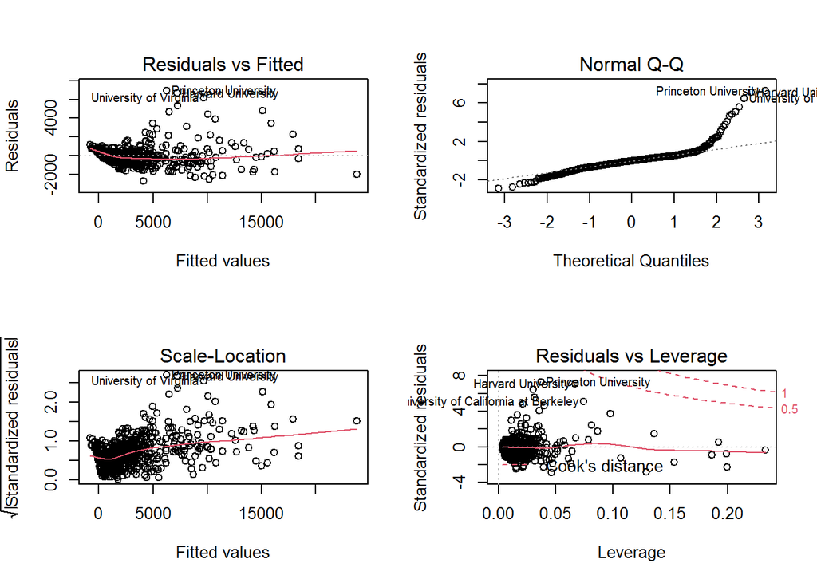

```r
par(mfrow=c(2, 2))
plot(model2_reg_trimmed)
```

```r
par(mfrow=c(1,1))
```

**Note**: see(1.6)

#### check normallity assumption

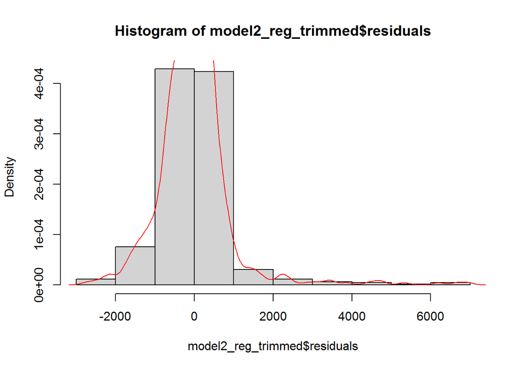

```r
hist(model2_reg_trimmed$residuals,probability = TRUE)
lines(density(model2_reg_trimmed$residuals),col="red")
```

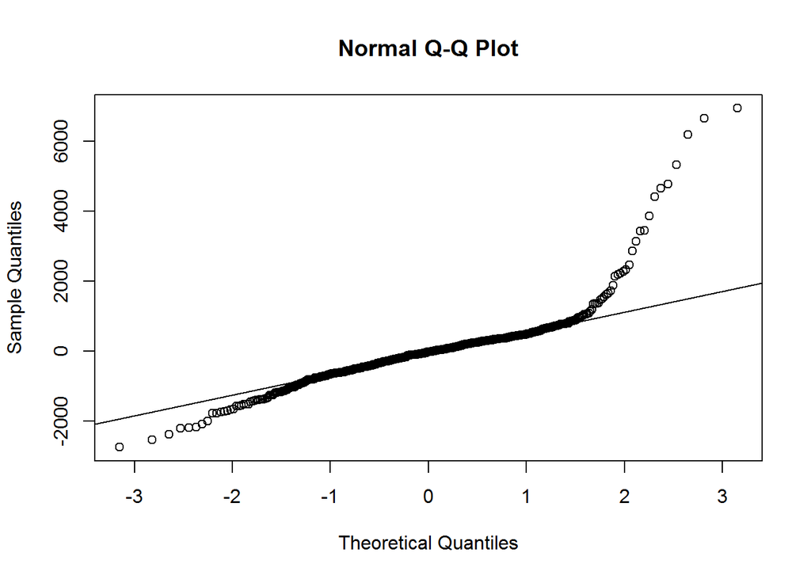

```r
qqnorm(model2_reg_trimmed$residuals)
qqline(model2_reg_trimmed$residuals)
```

```r
moments::anscombe.test(model2_reg_trimmed$residuals)
```

```
##
##  Anscombe-Glynn kurtosis test
##
## data:  model2_reg_trimmed$residuals
## kurt = 17.409, z = 12.053, p-value < 2.2e-16
## alternative hypothesis: kurtosis is not equal to 3
```

```r
moments::jarque.test(model2_reg_trimmed$residuals)
```

```
##
##  Jarque-Bera Normality Test
##
## data:  model2_reg_trimmed$residuals
## JB = 6003.8, p-value < 2.2e-16
## alternative hypothesis: greater
```

**Note** Residuals in model2_reg_trimmed are not normally distributed.

#### Check Multicollinearity(VIF)

```r
car::vif(model2_reg_trimmed)
```

```
##     Private      Accept   Top10perc   Top25perc F.Undergrad    Outstate
##    2.804904    7.317868    6.394883    5.459532    9.456695    3.945201
##  Room.Board      Expend   Grad.Rate    Terminal I(Enroll^2)
##    1.813034    2.435840    1.718049    1.821777    5.437578
```

**Note**: There isn’t any multicollinearity Between variables.

#### prediction

```r
pred_model2_reg_trimmed<-predict(model2_reg_trimmed,test)
```

#### absolute errors

```
## [1] 598.6364
```

```
## [1] 388.3004
```

```
## [1] 703.1411
```

```
## [1] 632.3569
```

```
## [1] 1.806988
```

```
## [1] 5073.721
```

```
## [1]    1.806988 5073.721399
```

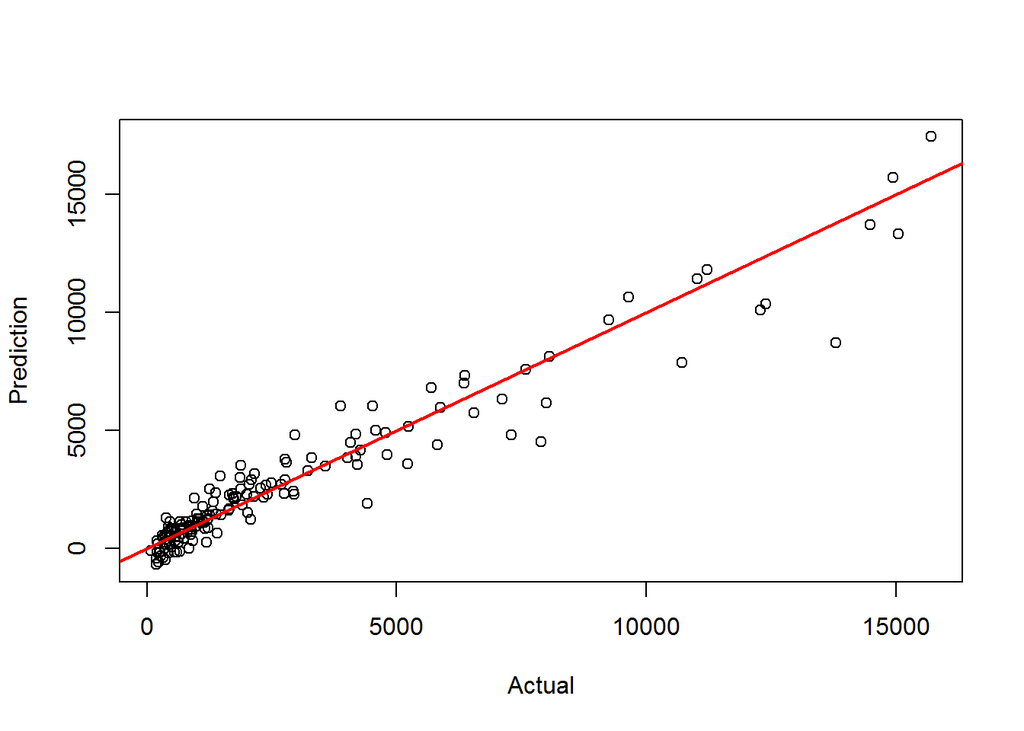

```r
plot(test$Apps, pred_model2_reg_trimmed, xlab = "Actual", ylab = "Prediction")
abline(a = 0, b = 1, col = "red", lwd = 2)
```

**Note** see(1.7)

### part6-f: Have the coefficients changed?

```r
#Compare Two models
coef(model2_reg)
```

```
##   (Intercept)     PrivateNo        Accept        Enroll     Top10perc
## -676.03581151  548.22917321    1.60918249   -1.01518176   49.48684084
##     Top25perc   F.Undergrad      Outstate    Room.Board        Expend
##  -12.92668723    0.08022416   -0.08452032    0.16225192    0.06171134
##     Grad.Rate      Terminal
##    8.16342480  -10.38174938
```

```r
coef(model2_reg_trimmed)
```

```
##   (Intercept)     PrivateNo        Accept     Top10perc     Top25perc
## -1.035149e+03  4.784473e+02  1.294853e+00  4.529936e+01 -1.344687e+01
##   F.Undergrad      Outstate    Room.Board        Expend     Grad.Rate
##  1.105586e-01 -4.808656e-02  1.844557e-01  5.753327e-02  9.748781e+00
##      Terminal   I(Enroll^2)
## -1.229727e+01 -1.068079e-04
```

**Note** see (1.8)

## part9: box_cox transformation method

#### finding the best lamda

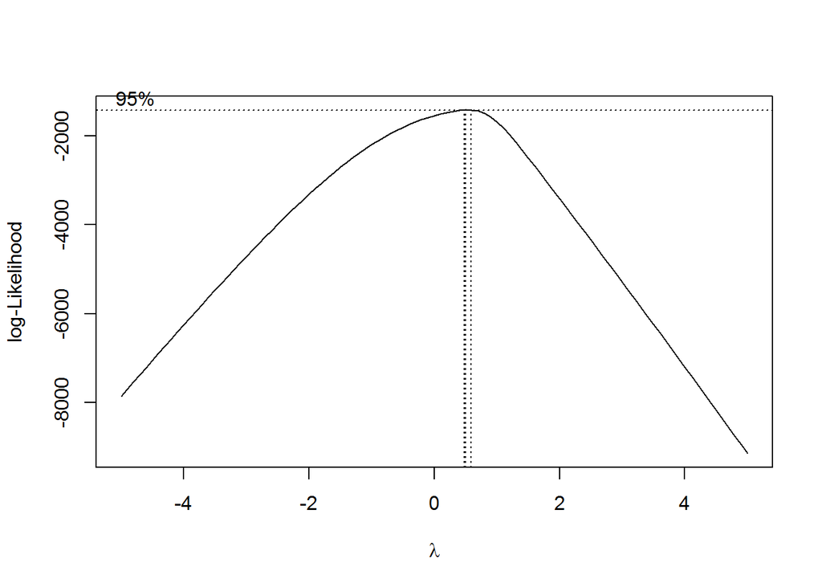

```r
box_result<- boxcox(Apps~.,data=train,lambda = seq(-5,5,0.1))
```

```r
box_result<-data.frame(box_result$x,box_result$y)
lambda<-box_result[which(box_result$box_result.y==max(box_result$box_result.y)),1]
lambda
```

```
## [1] 0.5
```

#### create Box_cox test and train data

```r
train$boxcox_apps<-((train$Apps^lambda)-1)/lambda
test$boxcox_apps<-((test$Apps^lambda)-1)/lambda
dim(train)
```

```
## [1] 621  20
```

```r
colnames(train)
```

```
##  [1] "Private"     "Apps"        "Accept"      "Enroll"      "Top10perc"
##  [6] "Top25perc"   "F.Undergrad" "P.Undergrad" "Outstate"    "Room.Board"
## [11] "Books"       "Personal"    "PhD"         "Terminal"    "S.F.Ratio"
## [16] "perc.alumni" "Expend"      "Grad.Rate"   "Elite"       "boxcox_apps"
```

### part9-a:linear regression based on Box-cox transformed data

#### full parameter model

```r
model3_boxcox_reg<-lm(boxcox_apps~.-Apps,data = train)
summary(model3_boxcox_reg)
```

```
##
## Call:
## lm(formula = boxcox_apps ~ . - Apps, data = train)
##
## Residuals:
##     Min      1Q  Median      3Q     Max
## -87.282  -8.881  -0.509   8.186  79.922
##
## Coefficients:
##               Estimate Std. Error t value Pr(>|t|)
## (Intercept) -2.749e+01  7.089e+00  -3.877 0.000117 ***
## PrivateNo    2.041e+01  2.535e+00   8.052 4.38e-15 ***
## Accept       1.343e-02  7.106e-04  18.904  < 2e-16 ***
## Enroll       7.332e-03  3.230e-03   2.270 0.023536 *
## Top10perc    3.227e-01  1.189e-01   2.713 0.006850 **
## Top25perc    2.645e-02  8.137e-02   0.325 0.745256
## F.Undergrad  1.593e-04  5.524e-04   0.288 0.773134
## P.Undergrad  1.012e-03  5.758e-04   1.758 0.079307 .
## Outstate     6.823e-04  3.410e-04   2.000 0.045895 *
## Room.Board   3.651e-03  8.557e-04   4.266 2.31e-05 ***
## Books        5.784e-03  4.097e-03   1.412 0.158534
## Personal     1.674e-03  1.134e-03   1.476 0.140333
## PhD          6.763e-02  8.247e-02   0.820 0.412479
## Terminal    -1.355e-02  8.996e-02  -0.151 0.880301
## S.F.Ratio    9.731e-01  2.348e-01   4.144 3.90e-05 ***
## perc.alumni -2.440e-01  7.482e-02  -3.262 0.001170 **
## Expend       1.122e-03  2.193e-04   5.116 4.20e-07 ***
## Grad.Rate    2.847e-01  5.442e-02   5.232 2.32e-07 ***
## EliteYes     5.616e+00  3.619e+00   1.552 0.121263
## ---
## Signif. codes:  0 '***' 0.001 '**' 0.01 '*' 0.05 '.' 0.1 ' ' 1
##
## Residual standard error: 16.72 on 602 degrees of freedom
## Multiple R-squared:  0.9099, Adjusted R-squared:  0.9072
## F-statistic: 337.6 on 18 and 602 DF,  p-value: < 2.2e-16
```

[figure not shown]

```r
par(mfrow=c(2, 2))
plot(model2_reg)
```

```r
par(mfrow=c(1,1))
```

### part9-b:linear regression based on Box-cox transformed data

```r
model4_boxcox_reg<-lm(boxcox_apps~Private+Accept+Enroll+Top10perc+Room.Board+S.F.Ratio +perc.alumni+Expend +Grad.Rate+ I(F.Undergrad ^2)+I(P.Undergrad ^(1/2)),data = train)
summary(model4_boxcox_reg)
```

```
##
## Call:
## lm(formula = boxcox_apps ~ Private + Accept + Enroll + Top10perc +
##     Room.Board + S.F.Ratio + perc.alumni + Expend + Grad.Rate +
##     I(F.Undergrad^2) + I(P.Undergrad^(1/2)), data = train)
##
## Residuals:
##     Min      1Q  Median      3Q     Max
## -74.805  -8.767  -0.764   7.970  83.357
##
## Coefficients:
##                        Estimate Std. Error t value Pr(>|t|)
## (Intercept)          -1.914e+01  5.416e+00  -3.535 0.000439 ***
## PrivateNo             1.635e+01  2.153e+00   7.596 1.15e-13 ***
## Accept                1.380e-02  6.549e-04  21.065  < 2e-16 ***
## Enroll                1.954e-02  2.435e-03   8.023 5.34e-15 ***
## Top10perc             4.894e-01  5.427e-02   9.019  < 2e-16 ***
## Room.Board            3.831e-03  7.542e-04   5.080 5.04e-07 ***
## S.F.Ratio             8.746e-01  2.197e-01   3.981 7.68e-05 ***
## perc.alumni          -1.581e-01  6.807e-02  -2.323 0.020512 *
## Expend                1.146e-03  1.926e-04   5.950 4.51e-09 ***
## Grad.Rate             2.392e-01  5.032e-02   4.753 2.50e-06 ***
## I(F.Undergrad^2)     -1.181e-07  1.351e-08  -8.740  < 2e-16 ***
## I(P.Undergrad^(1/2))  1.534e-01  5.258e-02   2.916 0.003673 **
## ---
## Signif. codes:  0 '***' 0.001 '**' 0.01 '*' 0.05 '.' 0.1 ' ' 1
##
## Residual standard error: 15.78 on 609 degrees of freedom
## Multiple R-squared:  0.9188, Adjusted R-squared:  0.9174
## F-statistic: 626.7 on 11 and 609 DF,  p-value: < 2.2e-16
```

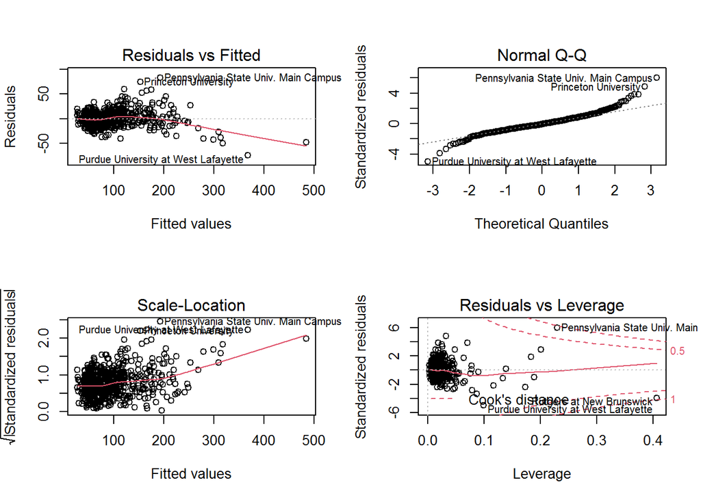

```r
par(mfrow=c(2, 2))
plot(model4_boxcox_reg)
```

```r
par(mfrow=c(1,1))
```

**Note** see(1.9)

#### check normallity assumption

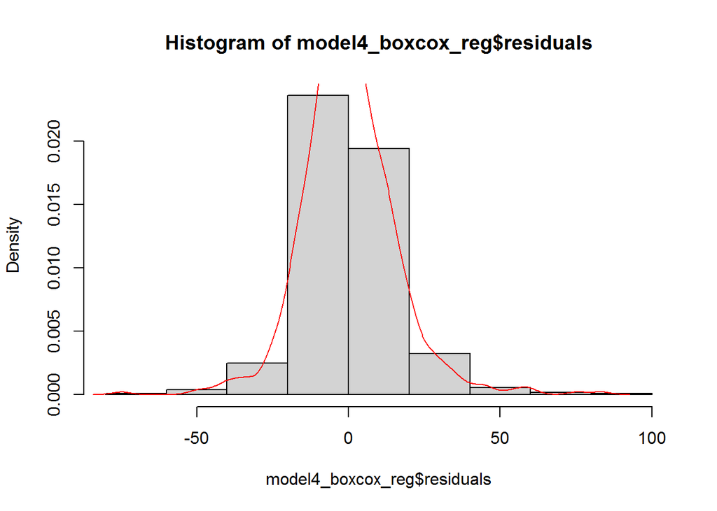

```r
hist(model4_boxcox_reg$residuals,probability = TRUE)
lines(density(model4_boxcox_reg$residuals),col="red")
```

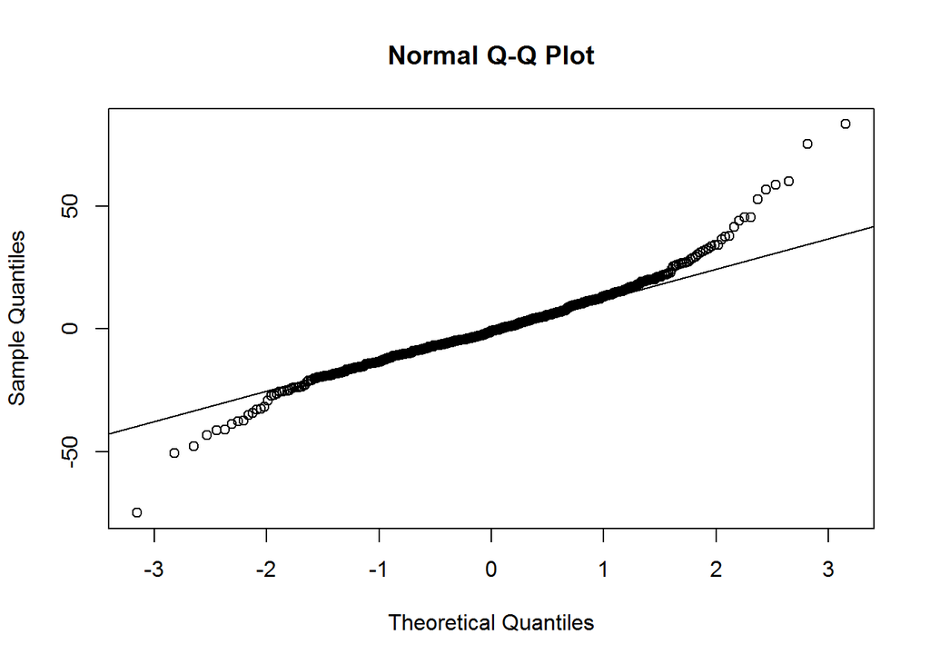

```r
qqnorm(model4_boxcox_reg$residuals)
qqline(model4_boxcox_reg$residuals)
```

```r
moments::anscombe.test(model4_boxcox_reg$residuals)
```

```
##
##  Anscombe-Glynn kurtosis test
##
## data:  model4_boxcox_reg$residuals
## kurt = 6.6643, z = 7.6655, p-value = 1.782e-14
## alternative hypothesis: kurtosis is not equal to 3
```

```r
moments::jarque.test(model4_boxcox_reg$residuals)
```

```
##
##  Jarque-Bera Normality Test
##
## data:  model4_boxcox_reg$residuals
## JB = 379.3, p-value < 2.2e-16
## alternative hypothesis: greater
```

**Note** residuals in model4_boxcox_reg are not normally distributed.

### part 9-c: VIF

```r
car::vif(model4_boxcox_reg)
```

```
##              Private               Accept               Enroll
##             2.289894             6.779097            12.842293
##            Top10perc           Room.Board            S.F.Ratio
##             2.256698             1.696154             1.827715
##          perc.alumni               Expend            Grad.Rate
##             1.795879             2.480533             1.813899
##     I(F.Undergrad^2) I(P.Undergrad^(1/2))
##             4.964675             2.256498
```

**Note**: There is multicollinearity in Enroll variable

#### prediction

```r
pred_model4_boxcox_reg<-predict(model4_boxcox_reg,test)
pred_model4_boxcox_reg<-((lambda*pred_model4_boxcox_reg)+1)^(1/lambda)
```

#### absolute errors

```
## [1] 626.0651
```

```
## [1] 354.5655
```

```
## [1] 935.0337
```

```
## [1] 520.2085
```

```
## [1] 1.926435
```

```
## [1] 5441.925
```

```
## [1]    1.926435 5441.925398
```

#### plot actual vs predicted

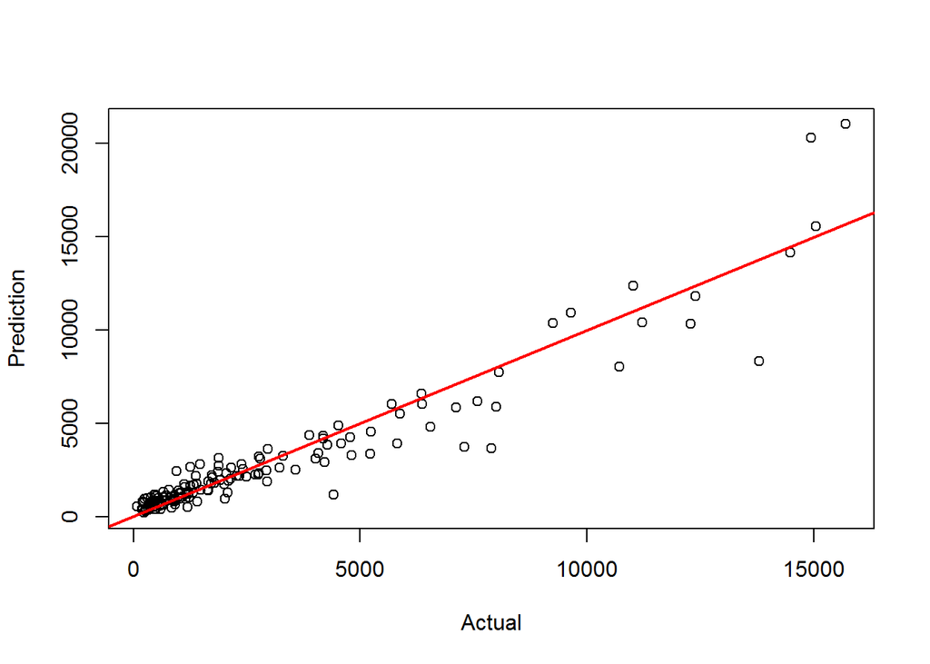

```r
plot(test$Apps,pred_model4_boxcox_reg, xlab = "Actual", ylab = "Prediction")
abline(a = 0, b = 1, col = "red", lwd = 2)
```

**Note**: see(1.10)

### part 9-d: linear regression based on Box-cox transformed data ion trimmed train data

#### Full parameter model

```r
train_trimmed_reg$boxcox_apps<-((train_trimmed_reg$Apps^lambda)-1)/lambda
model4_boxcox_reg_trimmed<-lm(boxcox_apps~.-Apps,data = train_trimmed_reg)
summary(model4_boxcox_reg_trimmed)
```

```
##
## Call:
## lm(formula = boxcox_apps ~ . - Apps, data = train_trimmed_reg)
##
## Residuals:
##     Min      1Q  Median      3Q     Max
## -98.942  -9.303  -0.055   7.922  81.798
##
## Coefficients:
##               Estimate Std. Error t value Pr(>|t|)
## (Intercept) -2.555e+01  7.029e+00  -3.635 0.000302 ***
## PrivateNo    2.008e+01  2.513e+00   7.992 6.87e-15 ***
## Accept       1.564e-02  9.240e-04  16.923  < 2e-16 ***
## Enroll       3.017e-03  3.395e-03   0.889 0.374464
## Top10perc    3.662e-01  1.181e-01   3.101 0.002018 **
## Top25perc    1.762e-02  8.049e-02   0.219 0.826787
## F.Undergrad -8.160e-07  5.480e-04  -0.001 0.998812
## P.Undergrad  1.091e-03  5.707e-04   1.912 0.056321 .
## Outstate     4.069e-04  3.454e-04   1.178 0.239240
## Room.Board   3.428e-03  8.480e-04   4.043 5.98e-05 ***
## Books        6.422e-03  4.057e-03   1.583 0.113931
## Personal     1.793e-03  1.125e-03   1.593 0.111589
## PhD          8.253e-02  8.265e-02   0.999 0.318372
## Terminal    -1.793e-02  8.911e-02  -0.201 0.840560
## S.F.Ratio    9.833e-01  2.322e-01   4.235 2.65e-05 ***
## perc.alumni -1.989e-01  7.489e-02  -2.656 0.008124 **
## Expend       1.129e-03  2.169e-04   5.207 2.64e-07 ***
## Grad.Rate    2.615e-01  5.476e-02   4.775 2.26e-06 ***
## EliteYes     4.748e+00  3.585e+00   1.325 0.185808
## ---
## Signif. codes:  0 '***' 0.001 '**' 0.01 '*' 0.05 '.' 0.1 ' ' 1
##
## Residual standard error: 16.54 on 599 degrees of freedom
## Multiple R-squared:  0.9063, Adjusted R-squared:  0.9034
## F-statistic: 321.7 on 18 and 599 DF,  p-value: < 2.2e-16
```

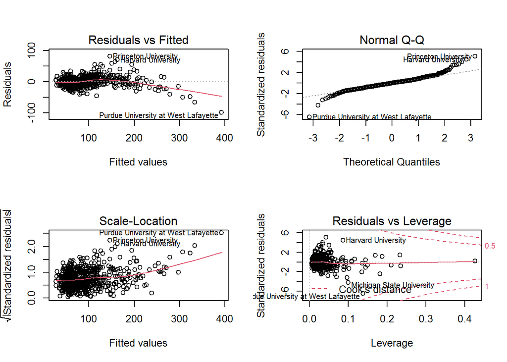

```r
par(mfrow=c(2, 2))
plot(model4_boxcox_reg_trimmed)
```

```r
par(mfrow=c(1,1))
```

**Note** The plot looks like a funnel, these are clear indicators that the given linear model is inappropriate.

### part 9-e: Model by significant variables

```r
model5_boxcox_reg_trimmed<-lm(boxcox_apps~Private+Accept+I(Enroll ^2)+Top10perc+Room.Board+S.F.Ratio +Expend +Grad.Rate+ I(F.Undergrad ^(1/2))+I(P.Undergrad ^(4)),data = train_trimmed_reg)
summary(model5_boxcox_reg_trimmed)
```

```
##
## Call:
## lm(formula = boxcox_apps ~ Private + Accept + I(Enroll^2) + Top10perc +
##     Room.Board + S.F.Ratio + Expend + Grad.Rate + I(F.Undergrad^(1/2)) +
##     I(P.Undergrad^(4)), data = train_trimmed_reg)
##
## Residuals:
##     Min      1Q  Median      3Q     Max
## -42.150  -7.871  -1.726   6.843  78.123
##
## Coefficients:
##                        Estimate Std. Error t value Pr(>|t|)
## (Intercept)          -1.914e+01  4.698e+00  -4.073 5.25e-05 ***
## PrivateNo             7.382e+00  2.009e+00   3.675 0.000259 ***
## Accept                1.705e-02  6.771e-04  25.179  < 2e-16 ***
## I(Enroll^2)          -3.756e-06  2.876e-07 -13.060  < 2e-16 ***
## Top10perc             3.888e-01  4.539e-02   8.564  < 2e-16 ***
## Room.Board            2.495e-03  6.348e-04   3.931 9.44e-05 ***
## S.F.Ratio             4.332e-01  1.923e-01   2.253 0.024603 *
## Expend                9.020e-04  1.665e-04   5.419 8.66e-08 ***
## Grad.Rate             1.774e-01  4.112e-02   4.314 1.87e-05 ***
## I(F.Undergrad^(1/2))  6.329e-01  4.890e-02  12.942  < 2e-16 ***
## I(P.Undergrad^(4))    1.254e-16  6.083e-17   2.061 0.039770 *
## ---
## Signif. codes:  0 '***' 0.001 '**' 0.01 '*' 0.05 '.' 0.1 ' ' 1
##
## Residual standard error: 13.63 on 607 degrees of freedom
## Multiple R-squared:  0.9355, Adjusted R-squared:  0.9344
## F-statistic: 880.3 on 10 and 607 DF,  p-value: < 2.2e-16
```

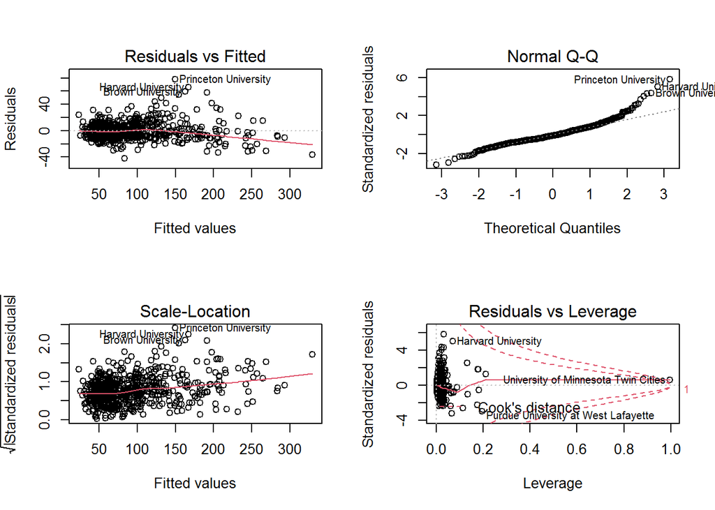

```r
par(mfrow=c(2, 2))
plot(model5_boxcox_reg_trimmed)
```

```r
par(mfrow=c(1,1))
```